# Study of the \( mu(z) \) and \( nu(z) \) candidates Rijndael's for 8 bit word size.

*This a working sheet, it is evolving and does not have conclusions*

In the standarized AES, based on the Rijndael candidate where only 3 key sizes where selected, the construction of the S-Boxes is based on the composition of two funtions. The first one, \( f \) understands the bits in the cells of the state matrix as elements of a binary polynomial finite field. The second one, \( g \) reinterpret the coefficients on the output of \( f \) as elements of a binary polynomial finite ring.

This \( g(x) \) is an affine mapping using two previously chosen polynomials \( mu(z) \) and \( nu(z) \): \[ b(z) = \mu(z) \cdot a(z) + \nu(z) = (z^4+z^3+z^2+z+1) \cdot a(z) + (z^6+z^5+z+1) \;\bmod{(z^8+1)} \]

But there are many other pairs of \( mu \) and \( nu \) that complain the requirements. Perhaps some of them even better. Conditions from section 7.2 of the “aes proposal” from 1999:

- \( mu(z) \) has a simple descritption
- \( nu(z) \) doesn't produce fixed points, neither oposite fixed points.

Those 21717 pairs are stored as observations in a csv file with information about the time used in the two ways to calculate the previous mention \( g \) function.

```r
ring8 = read.csv("20150318_111533_ring_degree_8.csv", header = TRUE, sep = "\t")
muOfficial <- ring8[which(ring8$muz == "z^4+z^3+z^2+z+1"), ]
official <- muOfficial[which(muOfficial$nuz == "z^6+z^5+z+1"), ]
library("scatterplot3d", lib.loc = "~/usr/lib/R/site-library")
```

The official \( mu(z)=z^4+z^3+z^2+z+1 \) and \( nu(z)=z^6+z^5+z+1 \) have to be highlighted to know if they are special above the others (based on this timing feature).

```r
summary(ring8)
```

```
##        mu            nu                             muz
##  Min.   :  1   Min.   :  2   1                        :  254
##  1st Qu.: 62   1st Qu.: 64   z^7+z^6+z^5+z^4+z^3+z^2+z:  253
##  Median :127   Median :128   z^6+z^4+z^2              :  251
##  Mean   :127   Mean   :128   z^7+z^5+z^3+z+1          :  251
##  3rd Qu.:193   3rd Qu.:192   z^5+z^4+z                :  247
##  Max.   :254   Max.   :255   z^6+z^5+z^2+z+1          :  247
##                              (Other)                  :20214
##         nuz         product_mean       product_std
##  z        :  128   Min.   :0.000067   Min.   :1.25e-05
##  z^2      :  128   1st Qu.:0.000117   1st Qu.:2.26e-05
##  z^2+z+1  :  128   Median :0.000126   Median :2.39e-05
##  z^3      :  128   Mean   :0.000125   Mean   :2.79e-05
##  z^3+z+1  :  128   3rd Qu.:0.000133   3rd Qu.:2.56e-05
##  z^3+z^2+1:  128   Max.   :0.000275   Max.   :2.60e-04
##  (Other)  :20949
##   matrix_mean         matrix_std
##  Min.   :0.000232   Min.   :1.14e-05
##  1st Qu.:0.000259   1st Qu.:1.55e-05
##  Median :0.000269   Median :1.71e-05
##  Mean   :0.000269   Mean   :2.80e-05
##  3rd Qu.:0.000273   3rd Qu.:2.64e-05
##  Max.   :0.000641   Max.   :8.78e-04
##
```

```r
summary(muOfficial)
```

```
##        mu           nu                     muz           nuz
##  Min.   :31   Min.   :  2.0   z^4+z^3+z^2+z+1:223   z      :  1
##  1st Qu.:31   1st Qu.: 64.5   1              :  0   z+1    :  1
##  Median :31   Median :128.0   z              :  0   z^2    :  1
##  Mean   :31   Mean   :128.1   z^2            :  0   z^2+1  :  1
##  3rd Qu.:31   3rd Qu.:191.5   z^2+z+1        :  0   z^2+z  :  1
##  Max.   :31   Max.   :254.0   z^3            :  0   z^2+z+1:  1
##                               (Other)        :  0   (Other):217
##   product_mean       product_std        matrix_mean
##  Min.   :0.000115   Min.   :2.35e-05   Min.   :0.000276
##  1st Qu.:0.000116   1st Qu.:2.46e-05   1st Qu.:0.000278
##  Median :0.000116   Median :2.50e-05   Median :0.000280
##  Mean   :0.000116   Mean   :2.52e-05   Mean   :0.000280
##  3rd Qu.:0.000117   3rd Qu.:2.56e-05   3rd Qu.:0.000281
##  Max.   :0.000134   Max.   :5.13e-05   Max.   :0.000316
##
##    matrix_std
##  Min.   :2.11e-05
##  1st Qu.:2.61e-05
##  Median :2.71e-05
##  Mean   :2.74e-05
##  3rd Qu.:2.81e-05
##  Max.   :7.97e-05
##
```

```r
summary(official)
```

```
##        mu           nu                  muz             nuz
##  Min.   :31   Min.   :99   z^4+z^3+z^2+z+1:1   z^6+z^5+z+1:1
##  1st Qu.:31   1st Qu.:99   1              :0   z          :0
##  Median :31   Median :99   z              :0   z+1        :0
##  Mean   :31   Mean   :99   z^2            :0   z^2        :0
##  3rd Qu.:31   3rd Qu.:99   z^2+z+1        :0   z^2+1      :0
##  Max.   :31   Max.   :99   z^3            :0   z^2+z      :0
##                            (Other)        :0   (Other)    :0
##   product_mean       product_std        matrix_mean
##  Min.   :0.000117   Min.   :2.51e-05   Min.   :0.000282
##  1st Qu.:0.000117   1st Qu.:2.51e-05   1st Qu.:0.000282
##  Median :0.000117   Median :2.51e-05   Median :0.000282
##  Mean   :0.000117   Mean   :2.51e-05   Mean   :0.000282
##  3rd Qu.:0.000117   3rd Qu.:2.51e-05   3rd Qu.:0.000282
##  Max.   :0.000117   Max.   :2.51e-05   Max.   :0.000282
##
##    matrix_std
##  Min.   :2.78e-05
##  1st Qu.:2.78e-05
##  Median :2.78e-05
##  Mean   :2.78e-05
##  3rd Qu.:2.78e-05
##  Max.   :2.78e-05
##
```

It is unknown why \( mu(z)=z^4+z^3+z^2+z+1 \) was chosen above the other candidates, and the criteria to chose \( nu(z)=z^6+z^5+z+1 \), even it is much more precise, doesn't clarify why it between the \( 223 \) alternatives.

How different is the time, in general between those two method? The \( g \) function using product versus matrix methods:

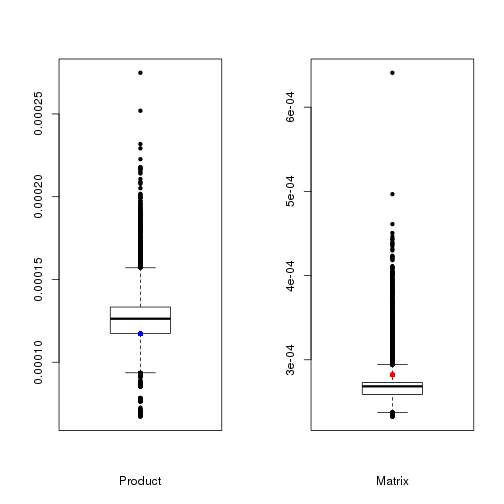

```r
par(mfrow = c(1, 2))
boxplot(ring8$product_mean, pch = 20, xlab = "Product")
points(official$product_mean, col = "blue", pch = 16)
boxplot(ring8$matrix_mean, pch = 20, xlab = "Matrix")
points(official$matrix_mean, col = "red", pch = 16)
```

Having those two options with the same axis, is the matrix method worst than the simple product?

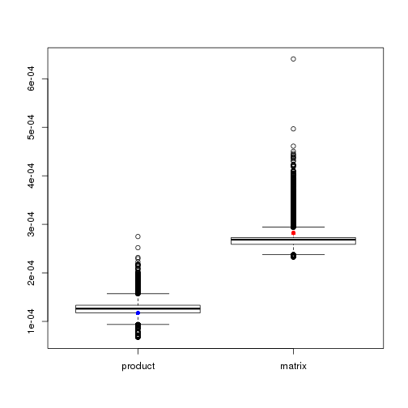

```r
boxplot(ring8$product_mean, ring8$matrix_mean, names = c("product", "matrix"))
points(official$product_mean, col = "blue", x = 1, pch = 16)
points(official$matrix_mean, col = "red", x = 2, pch = 16)
```

And from the set of the \( 223 \) alternatives for a fixed \( mu(z)=z^4+z^3+z^2+z+1 \):

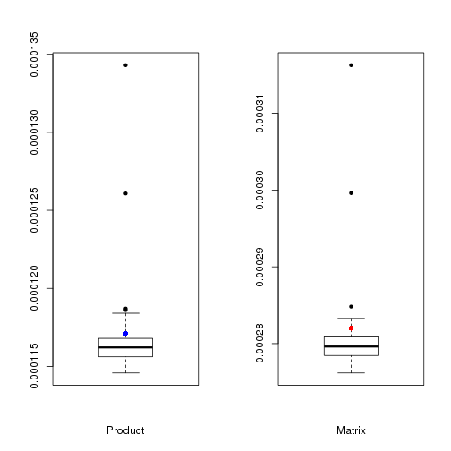

```r
par(mfrow = c(1, 2))
boxplot(muOfficial$product_mean, pch = 20, xlab = "Product")
points(official$product_mean, col = "blue", pch = 16)
boxplot(muOfficial$matrix_mean, pch = 20, xlab = "Matrix")
points(official$matrix_mean, col = "red", pch = 16)
```

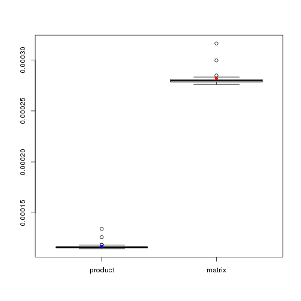

```r
boxplot(muOfficial$product_mean, muOfficial$matrix_mean, names = c("product",
    "matrix"))
points(official$product_mean, col = "blue", x = 1, pch = 16)
points(official$matrix_mean, col = "red", x = 2, pch = 16)
```

## Other plots

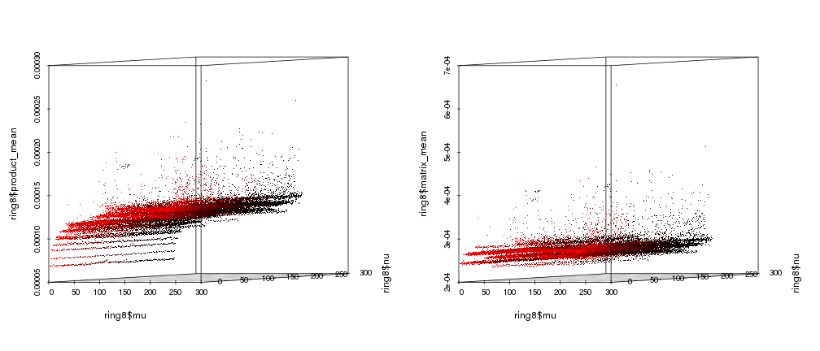

```r
par(mfrow = c(1, 2))
scatterplot3d(ring8$mu, ring8$nu, ring8$product_mean, pch = ".", angle = 3,
    highlight.3d = TRUE, )
scatterplot3d(ring8$mu, ring8$nu, ring8$matrix_mean, pch = ".", angle = 3, highlight.3d = TRUE,
    )
```

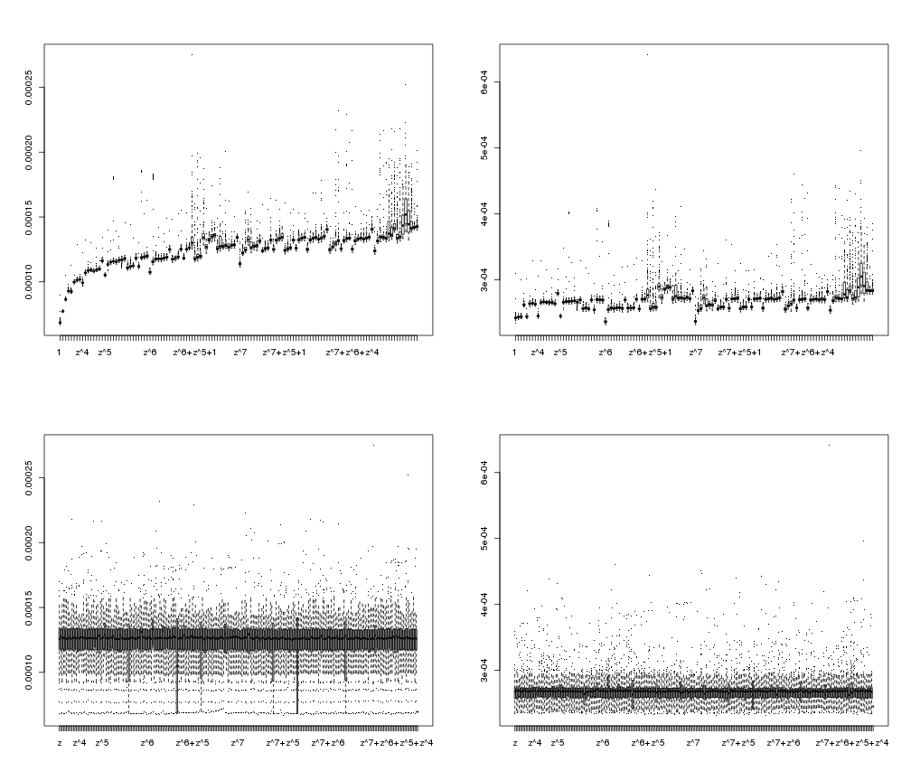

```r
par(mfrow = c(2, 2))
plot(ring8$muz, ring8$product_mean, pch = ".")
plot(ring8$muz, ring8$matrix_mean, pch = ".")
plot(ring8$nuz, ring8$product_mean, pch = ".")
plot(ring8$nuz, ring8$matrix_mean, pch = ".")
```

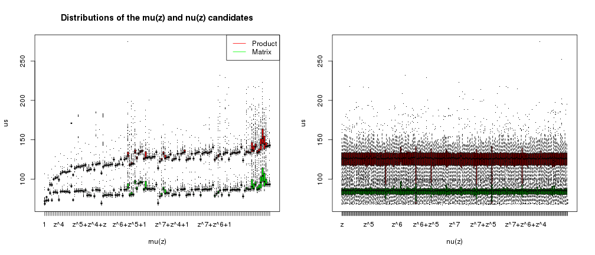

```r
par(mfrow = c(1, 2))
plot(ring8$muz, ring8$product_mean * 1e+06, pch = ".", xlab = "mu(z)", col = "red",
    ylab = "us")
legend("topright", c("Product", "Matrix"), lty = 1, col = c("red", "green"))
par(new = TRUE)
plot(ring8$muz, ring8$matrix_mean * 1e+06, pch = ".", col = "green", axes = F)
par(new = TRUE)
plot(official$muz, official$matrix_mean * 1e+06, pch = 16, col = "blue", axes = F)
title("Distributions of the mu(z) and nu(z) candidates")
plot(ring8$nuz, ring8$product_mean * 1e+06, pch = ".", xlab = "nu(z)", col = "red",
    ylab = "us")
par(new = TRUE)
plot(ring8$nuz, ring8$matrix_mean * 1e+06, pch = ".", col = "green", axes = F)
```